# R vs. Python

Dr. Shirin Glander

2017-01-20

I am an avid R user and rarely use anything else for data analysis and visualisation.

I wanted to see how R and Python fare in a one-to-one comparison, i.e. whether one might be faster/ easier to use than the other.

Therefore, I am following [Zhuyi Xue’s “A Comprehensive Introduction To Your Genome With the SciPy Stack”](https://www.toptal.com/python/comprehensive-introduction-your-genome-scipy) (with some minor tweaks here and there) to compare his analysis with how I would run it in R. I want to know whether one or the other tool is better suited to this type of analysis.

He gives a nice introduction to the data, so I will not repeat it here but focus on the comparison between the Python code with R.

For R, I am working with RStudio, for Python with Anaconda and Spyder.

While the code could be replicated with base R, I find it more elegant to use dplyr and ggplot2.

```r
library(dplyr)
library(ggplot2)
```

### Reading in data

Reading in data as csv files is straight forward in both R and Python with the exception that R opens compressed files without having to specify the compression format as in Python/pandas.

*Python:*

```python
import pandas as pd

df = pd.read_csv('../../Homo_sapiens.GRCh38.85.gff3.gz',
                         compression = 'gzip',
                         sep = '\t',
                         comment = '#',
                         low_memory = False,
                         header = None,
                         names = ['seqid', 'source', 'type', 'start', 'end', 'score', 'strand', 'phase', 'attributes'])
df.head()
```

*R:*

```r
df <- read.csv("../../Homo_sapiens.GRCh38.85.gff3.gz",
               header = FALSE,
               sep = "\t",
               col.names = c('seqid', 'source', 'type', 'start', 'end', 'score', 'strand', 'phase', 'attributes'),
               comment.char = "#")
head(df)
```

```
##   seqid source              type start       end   score strand phase
## 1     1 GRCh38        chromosome     1 248956422       .      .     .
## 2     1      . biological_region 10469     11240 1.3e+03      .     .
## 3     1      . biological_region 10650     10657   0.999      +     .
## 4     1      . biological_region 10655     10657   0.999      -     .
## 5     1      . biological_region 10678     10687   0.999      +     .
## 6     1      . biological_region 10681     10688   0.999      -     .
##                                           attributes
## 1 ID=chromosome:1;Alias=CM000663.2,chr1,NC_000001.11
## 2           external_name=oe %3D 0.79;logic_name=cpg
## 3                                 logic_name=eponine
## 4                                 logic_name=eponine
## 5                                 logic_name=eponine
## 6                                 logic_name=eponine
```

### Examining data

- listing unique strings of “seqid” column

*Python:*

```python
df.seqid.unique() # alternatively: df['seqid'].unique()
```

*R:*

```r
unique(df$seqid)
```

```
##   [1] 1          10         11         12         13         14
##   [7] 15         16         17         18         19         2
##  [13] 20         21         22         3          4          5
##  [19] 6          7          8          9          GL000008.2 GL000009.2
##  [25] GL000194.1 GL000195.1 GL000205.2 GL000208.1 GL000213.1 GL000214.1
##  [31] GL000216.2 GL000218.1 GL000219.1 GL000220.1 GL000221.1 GL000224.1
##  [37] GL000225.1 GL000226.1 KI270302.1 KI270303.1 KI270304.1 KI270305.1
##  [43] KI270310.1 KI270311.1 KI270312.1 KI270315.1 KI270316.1 KI270317.1
##  [49] KI270320.1 KI270322.1 KI270329.1 KI270330.1 KI270333.1 KI270334.1
##  [55] KI270335.1 KI270336.1 KI270337.1 KI270338.1 KI270340.1 KI270362.1
##  [61] KI270363.1 KI270364.1 KI270366.1 KI270371.1 KI270372.1 KI270373.1
##  [67] KI270374.1 KI270375.1 KI270376.1 KI270378.1 KI270379.1 KI270381.1
##  [73] KI270382.1 KI270383.1 KI270384.1 KI270385.1 KI270386.1 KI270387.1
##  [79] KI270388.1 KI270389.1 KI270390.1 KI270391.1 KI270392.1 KI270393.1
##  [85] KI270394.1 KI270395.1 KI270396.1 KI270411.1 KI270412.1 KI270414.1
```

[output cut: 19 more lines]

- how many unique seqids are there?

*Python:*

```python
df.seqid.unique().shape
```

*R:*

```r
length(unique(df$seqid))
```

```
## [1] 194
```

- counting occurrences of items in the “source” column

*Python:*

```python
df.source.value_counts()
```

*R:*

```r
# table(df$source) is per default ordered alphabetically, if we want it ordered by decreasing counts, like with Python:
sort(table(df$source), decreasing = TRUE)
```

```
##
##         havana ensembl_havana        ensembl              .        mirbase
##        1441093         745065         228212         182510           4701
##         GRCh38          insdc
##            194             74
```

#### How Much of the Genome Is Incomplete?

- subsetting a dataframe

*Python:*

```python
gdf = df[df.source == 'GRCh38']

gdf.shape
gdf.sample(10)
```

*R:*

```r
gdf <- subset(df, source == "GRCh38")

# get number of rows and columns
dim(gdf)
```

```
## [1] 194   9
```

```r
# randomly sample 10 rows for observation
sample_n(gdf, 10)
```

```
##              seqid source        type start       end score strand phase
## 2511545 KI270466.1 GRCh38 supercontig     1      1233     .      .     .
## 1964922          5 GRCh38  chromosome     1 181538259     .      .     .
## 2511557 KI270518.1 GRCh38 supercontig     1      2186     .      .     .
## 2513997 KI270755.1 GRCh38 supercontig     1     36723     .      .     .
## 865054          16 GRCh38  chromosome     1  90338345     .      .     .
## 2511500 KI270393.1 GRCh38 supercontig     1      1308     .      .     .
## 2512137 KI270713.1 GRCh38 supercontig     1     40745     .      .     .
## 2511514 KI270425.1 GRCh38 supercontig     1      1884     .      .     .
## 2511517 KI270438.1 GRCh38 supercontig     1    112505     .      .     .
## 2513949 KI270751.1 GRCh38 supercontig     1    150742     .      .     .
##                                                                 attributes
## 2511545       ID=supercontig:KI270466.1;Alias=chrUn_KI270466v1,NT_187421.1
## 1964922                 ID=chromosome:5;Alias=CM000667.2,chr5,NC_000005.10
## 2511557       ID=supercontig:KI270518.1;Alias=chrUn_KI270518v1,NT_187429.1
## 2513997       ID=supercontig:KI270755.1;Alias=chrUn_KI270755v1,NT_187510.1
## 865054                ID=chromosome:16;Alias=CM000678.2,chr16,NC_000016.10
## 2511500       ID=supercontig:KI270393.1;Alias=chrUn_KI270393v1,NT_187483.1
## 2512137 ID=supercontig:KI270713.1;Alias=chr1_KI270713v1_random,NT_187368.1
## 2511514       ID=supercontig:KI270425.1;Alias=chrUn_KI270425v1,NT_187418.1
## 2511517       ID=supercontig:KI270438.1;Alias=chrUn_KI270438v1,NT_187425.1
## 2513949       ID=supercontig:KI270751.1;Alias=chrUn_KI270751v1,NT_187506.1
```

Viewing 10 random lines is more straight forward in Python but in R I’d usually use head() to get an idea of a dataframe.

- calculate the sum of seqid lengths

*Python:*

```python
gdf = gdf.copy()
gdf['length'] = gdf.end - gdf.start + 1

gdf.length.sum()
```

*R:*

```r
gdf$length <- gdf$end - gdf$start + 1

sum(gdf$length)
```

```
## [1] 3096629726
```

In R we don’t need to copy the dataframe first.

- calculate the proportio of the genome that is not on main chromosome assemblies

*Python:*

```python
chrs = [str(_) for _ in range(1, 23)] + ['X', 'Y', 'MT']
gdf[-gdf.seqid.isin(chrs)].length.sum() / gdf.length.sum()

# or
gdf[(gdf['type'] == 'supercontig')].length.sum() / gdf.length.sum()
```

*R:*

```r
chrs <- c(1:23, "X", "Y", "MT")
sum(subset(gdf, !seqid %in% chrs)$length) / sum(gdf$length)
```

```
## [1] 0.003702192
```

#### How Many Genes Are There?

*Python:*

```python
edf = df[df.source.isin(['ensembl', 'havana', 'ensembl_havana'])]
edf.shape

edf.sample(10)
edf.type.value_counts()
```

*R:*

```r
edf <- subset(df, source %in% c("ensembl", "havana", "ensembl_havana"))
dim(edf)
```

```
## [1] 2414370       9
```

```r
sample_n(edf, 10)
```

```
##         seqid         source                          type     start
## 946774     16         havana                          exon  57655399
## 1009835    17         havana                five_prime_UTR   7252376
## 258096     10 ensembl_havana                           CDS  35566023
## 925218     16         havana                          exon  30094789
## 72748       1         havana                          exon  44632343
## 1814924     3 ensembl_havana aberrant_processed_transcript 134356185
## 1486927     2         havana                          exon 170542906
## 2443613     9         havana                          exon  65692571
## 918110     16 ensembl_havana                          exon  28477516
## 1194956    18 ensembl_havana                          exon  63637259
##               end score strand phase
## 946774   57655530     .      +     .
## 1009835   7252502     .      +     .
## 258096   35566185     .      +     1
```

[output cut: 18 more lines]

```r
sort(table(edf$type), decreasing = TRUE)
```

```
##
##                          exon                           CDS
##                       1180596                        704604
##                five_prime_UTR               three_prime_UTR
##                        142387                        133938
##                    transcript                          gene
##                         96375                         42470
##          processed_transcript aberrant_processed_transcript
##                         28228                         26944
##        NMD_transcript_variant                       lincRNA
##                         13761                         13247
##          processed_pseudogene                  lincRNA_gene
##                         10722                          7533
##                    pseudogene                           RNA
##                          3049                          2221
##                         snRNA                    snRNA_gene
##                          1909                          1909
##                        snoRNA                   snoRNA_gene
##                           956                           944
##        pseudogenic_transcript                          rRNA
##                           737                           549
##                     rRNA_gene                         miRNA
##                           549                           302
##                V_gene_segment                J_gene_segment
##                           216                           158
##               VD_gene_segment                C_gene_segment
##                            37                            29
##             biological_region                    chromosome
##                             0                             0
##                    miRNA_gene                       mt_gene
##                             0                             0
##                   supercontig
##                             0
```

*Python:*

```python
ndf = edf[edf.type == 'gene']
ndf = ndf.copy()
ndf.sample(10).attributes.values
ndf.shape
```

*R:*

```r
ndf <- subset(edf, type == "gene")
sample_n(ndf, 10)$attributes
```

```
##  [1] ID=gene:ENSG00000224701;Name=MED28P4;biotype=processed_pseudogene;description=mediator complex subunit 28 pseudogene 4 [Source:HGNC Symbol%3BAcc:HGNC:45081];gene_id=ENSG00000224701;havana_gene=OTTHUMG00000021412;havana_version=1;logic_name=havana;version=1
##  [2] ID=gene:ENSG00000250655;Name=RP11-61G24.1;biotype=processed_pseudogene;gene_id=ENSG00000250655;havana_gene=OTTHUMG00000160944;havana_version=1;logic_name=havana;version=1
##  [3] ID=gene:ENSG00000213569;Name=RP13-383K5.4;biotype=processed_pseudogene;gene_id=ENSG00000213569;havana_gene=OTTHUMG00000022158;havana_version=2;logic_name=havana;version=4
##  [4] ID=gene:ENSG00000083937;Name=CHMP2B;biotype=protein_coding;description=charged multivesicular body protein 2B [Source:HGNC Symbol%3BAcc:HGNC:24537];gene_id=ENSG00000083937;havana_gene=OTTHUMG00000158982;havana_version=4;logic_name=ensembl_havana_gene;version=8
##  [5] ID=gene:ENSG00000204195;Name=AWAT1;biotype=protein_coding;description=acyl-CoA wax alcohol acyltransferase 1 [Source:HGNC Symbol%3BAcc:HGNC:23252];gene_id=ENSG00000204195;havana_gene=OTTHUMG00000021773;havana_version=3;logic_name=ensembl_havana_gene;version=3
##  [6] ID=gene:ENSG00000263159;Name=RP11-462G12.4;biotype=antisense;gene_id=ENSG00000263159;havana_gene=OTTHUMG00000177614;havana_version=1;logic_name=havana;version=1
##  [7] ID=gene:ENSG00000280088;Name=RP11-135F9.3;biotype=TEC;gene_id=ENSG00000280088;havana_gene=OTTHUMG00000170196;havana_version=1;logic_name=havana;version=1
##  [8] ID=gene:ENSG00000223974;Name=BNIP3P42;biotype=processed_pseudogene;description=BCL2/adenovirus E1B 19kDa interacting protein 3 pseudogene 42 [Source:HGNC Symbol%3BAcc:HGNC:49722];gene_id=ENSG00000223974;havana_gene=OTTHUMG00000156543;havana_version=1;logic_name=havana;version=1
##  [9] ID=gene:ENSG00000150347;Name=ARID5B;biotype=protein_coding;description=AT-rich interaction domain 5B [Source:HGNC Symbol%3BAcc:HGNC:17362];gene_id=ENSG00000150347;havana_gene=OTTHUMG00000018298;havana_version=1;logic_name=ensembl_havana_gene;version=14
## [10] ID=gene:ENSG00000225693;Name=LAGE3P1;biotype=processed_pseudogene;description=L antigen family member 3 pseudogene 1 [Source:HGNC Symbol%3BAcc:HGNC:49909];gene_id=ENSG00000225693;havana_gene=OTTHUMG00000019761;havana_version=1;logic_name=havana;version=1
## 1623077 Levels: ID=CDS:ENSP00000000233;Parent=transcript:ENST00000000233;protein_id=ENSP00000000233 ...
```

```r
dim(ndf)
```

```
## [1] 42470     9
```

- extracting gene information from attributes field

I don’t know if there is an easier way in Python but in R we don’t need to create a helper function around it. We can simply use gsub()…

*Python:*

```python
import re

RE_GENE_NAME = re.compile(r'Name=(?P<gene_name>.+?);')
def extract_gene_name(attributes_str):
    res = RE_GENE_NAME.search(attributes_str)
    return res.group('gene_name')


ndf['gene_name'] = ndf.attributes.apply(extract_gene_name)

RE_GENE_ID = re.compile(r'gene_id=(?P<gene_id>ENSG.+?);')
def extract_gene_id(attributes_str):
    res = RE_GENE_ID.search(attributes_str)
    return res.group('gene_id')


ndf['gene_id'] = ndf.attributes.apply(extract_gene_id)


RE_DESC = re.compile('description=(?P<desc>.+?);')
def extract_description(attributes_str):
    res = RE_DESC.search(attributes_str)
    if res is None:
        return ''
    else:
        return res.group('desc')


ndf['desc'] = ndf.attributes.apply(extract_description)

ndf.drop('attributes', axis=1, inplace=True)
ndf.head()
```

*R:*

```r
ndf$gene_name <- gsub("(.*Name=)(.*?)(;biotype.*)", "\\2", ndf$attributes)
ndf$gene_id <- gsub("(ID=gene:)(.*?)(;Name.*)", "\\2", ndf$attributes)
ndf$desc <- gsub("(.*description=)(.*?)(;.*)", "\\2", ndf$attributes)

# some genes don't have a description
ndf$desc <- ifelse(grepl("^ID=.*", ndf$desc), "", ndf$desc)

ndf <- subset(ndf, select = -attributes)
head(ndf, n = 10)
```

```
##     seqid         source type  start    end score strand phase
## 17      1         havana gene  11869  14409     .      +     .
## 29      1         havana gene  14404  29570     .      -     .
## 72      1         havana gene  52473  53312     .      +     .
## 75      1         havana gene  62948  63887     .      +     .
## 78      1 ensembl_havana gene  69091  70008     .      +     .
## 109     1         havana gene 131025 134836     .      +     .
## 113     1         havana gene 135141 135895     .      -     .
## 119     1         havana gene 137682 137965     .      -     .
## 122     1         havana gene 139790 140339     .      -     .
## 167     1        ensembl gene 182393 184158     .      +     .
##         gene_name         gene_id
## 17        DDX11L1 ENSG00000223972
## 29         WASH7P ENSG00000227232
## 72         OR4G4P ENSG00000268020
```

[output cut: 18 more lines]

*Python:*

```python
ndf.shape
ndf.gene_id.unique().shape
ndf.gene_name.unique().shape

count_df = ndf.groupby('gene_name').count().ix[:, 0].sort_values().ix[::-1]
count_df.head(10)
```

*R:*

```r
dim(ndf)
```

```
## [1] 42470    11
```

```r
length(unique(ndf$gene_id))
```

```
## [1] 42470
```

```r
length(unique(ndf$gene_name))
```

```
## [1] 42387
```

#### How Long Is a Typical Gene?

*Python:*

```python
ndf['length'] = ndf.end - ndf.start + 1
ndf.length.describe()
```

*R:*

```r
ndf$length <- ndf$end - ndf$start + 1
summary(ndf$length)
```

```
##    Min. 1st Qu.  Median    Mean 3rd Qu.    Max.
##       8     884    5170   35830   30550 2305000
```

R’s summary() is not exactly the same as Python’s describe() but it’s close enough.

*Python:*

```python
import matplotlib as plt

ndf.length.plot(kind='hist', bins=50, logy=True)
plt.show()
```

In base R you can’t really plot a histogram with logarithmic y-axis scales (and it isn’t recommended either because 0 will become -Inf) but you can do it easily with ggplot2.

*R:*

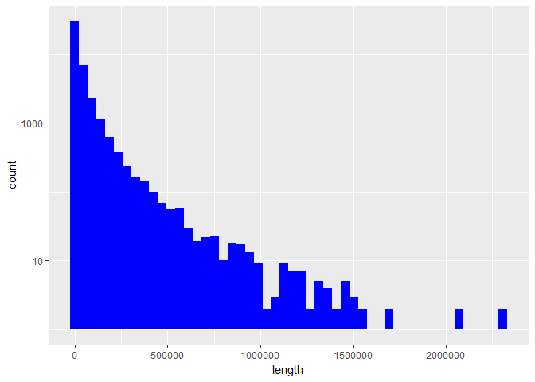

```r
ggplot(ndf, aes(x = length)) +
  geom_histogram(bins = 50, fill = "blue") +
  scale_y_log10()
```

*Python:*

```python
ndf[ndf.length > 2e6].sort_values('length').ix[::-1]
```

*R:*

```r
ndf %>%
  filter(length > 2e6) %>%
  arrange(desc(length))
```

```
##   seqid         source type     start       end score strand phase
## 1     7 ensembl_havana gene 146116002 148420998     .      +     .
## 2     9 ensembl_havana gene   8314246  10612723     .      -     .
## 3     X ensembl_havana gene  31097677  33339441     .      -     .
## 4    11 ensembl_havana gene  83455012  85627922     .      -     .
## 5     8 ensembl_havana gene   2935353   4994972     .      -     .
## 6    20 ensembl_havana gene  13995369  16053197     .      +     .
##   gene_name         gene_id
## 1   CNTNAP2 ENSG00000174469
## 2     PTPRD ENSG00000153707
## 3       DMD ENSG00000198947
## 4      DLG2 ENSG00000150672
## 5     CSMD1 ENSG00000183117
## 6   MACROD2 ENSG00000172264
##                                                                                   desc
## 1            contactin associated protein-like 2 [Source:HGNC Symbol%3BAcc:HGNC:13830]
## 2 protein tyrosine phosphatase%2C receptor type D [Source:HGNC Symbol%3BAcc:HGNC:9668]
## 3                                      dystrophin [Source:HGNC Symbol%3BAcc:HGNC:2928]
## 4            discs large MAGUK scaffold protein 2 [Source:HGNC Symbol%3BAcc:HGNC:2901]
## 5               CUB and Sushi multiple domains 1 [Source:HGNC Symbol%3BAcc:HGNC:14026]
## 6                      MACRO domain containing 2 [Source:HGNC Symbol%3BAcc:HGNC:16126]
##    length
## 1 2304997
## 2 2298478
## 3 2241765
## 4 2172911
## 5 2059620
## 6 2057829
```

*Python:*

```python
ndf.sort_values('length').head()
```

*R:*

```r
head(arrange(ndf, length))
```

```
##   seqid source type     start       end score strand phase    gene_name
## 1    14 havana gene  22438547  22438554     .      +     .        TRDD1
## 2    14 havana gene  22439007  22439015     .      +     .        TRDD2
## 3     7 havana gene 142786213 142786224     .      +     .        TRBD1
## 4    14 havana gene  22449113  22449125     .      +     .        TRDD3
## 5     4 havana gene  10238213  10238235     .      -     .   AC006499.9
## 6     3 havana gene 179452395 179452419     .      -     . RP11-145M9.2
##           gene_id
## 1 ENSG00000223997
## 2 ENSG00000237235
## 3 ENSG00000282431
## 4 ENSG00000228985
## 5 ENSG00000271544
## 6 ENSG00000239255
##                                                                      desc
## 1 T cell receptor delta diversity 1 [Source:HGNC Symbol%3BAcc:HGNC:12254]
## 2 T cell receptor delta diversity 2 [Source:HGNC Symbol%3BAcc:HGNC:12255]
## 3  T cell receptor beta diversity 1 [Source:HGNC Symbol%3BAcc:HGNC:12158]
## 4 T cell receptor delta diversity 3 [Source:HGNC Symbol%3BAcc:HGNC:12256]
## 5
## 6
##   length
## 1      8
## 2      9
## 3     12
## 4     13
## 5     23
## 6     25
```

#### Gene Distribution Among Chromosomes

*Python:*

```python
ndf = ndf[ndf.seqid.isin(chrs)]
chr_gene_counts = ndf.groupby('seqid').count().ix[:, 0].sort_values().ix[::-1]
chr_gene_counts
```

*R:*

```r
ndf$seqid <- as.character(ndf$seqid) # as factors it will subset the dataframe but keep the factor levels
ndf <- subset(ndf, seqid %in% chrs)
chr_gene_counts <- sort(table(ndf$seqid), decreasing = TRUE)
chr_gene_counts
```

```
##
##    1    2   11   19   17    3    6   12    7    5   16    X    4    9    8
## 3902 2806 2561 2412 2280 2204 2154 2140 2106 2002 1881 1852 1751 1659 1628
##   10   15   14   22   20   13   18   21    Y
## 1600 1476 1449  996  965  872  766  541  436
```

*Python:*

```python
df[(df.type == 'gene') & (df.seqid == 'MT')]
```

*R:*

```r
subset(df, type == "gene" & seqid == "MT")
```

```
##         seqid source type start   end score strand phase
## 2514004    MT  insdc gene   648  1601     .      +     .
## 2514010    MT  insdc gene  1671  3229     .      +     .
## 2514017    MT  insdc gene  3307  4262     .      +     .
## 2514030    MT  insdc gene  4470  5511     .      +     .
## 2514049    MT  insdc gene  5904  7445     .      +     .
## 2514059    MT  insdc gene  7586  8269     .      +     .
## 2514066    MT  insdc gene  8366  8572     .      +     .
## 2514070    MT  insdc gene  8527  9207     .      +     .
## 2514074    MT  insdc gene  9207  9990     .      +     .
## 2514081    MT  insdc gene 10059 10404     .      +     .
## 2514088    MT  insdc gene 10470 10766     .      +     .
## 2514092    MT  insdc gene 10760 12137     .      +     .
## 2514105    MT  insdc gene 12337 14148     .      +     .
## 2514109    MT  insdc gene 14149 14673     .      -     .
```

[output cut: 17 more lines]

*Python:*

```python
gdf = gdf[gdf.seqid.isin(chrs)]
gdf.drop(['start', 'end', 'score', 'strand', 'phase' ,'attributes'], axis=1, inplace=True)
gdf.sort_values('length').ix[::-1]
```

*R:*

```r
gdf$seqid <- as.character(gdf$seqid) # as factors it will subset the dataframe but keep the factor levels
gdf <- subset(gdf, as.character(seqid) %in% chrs) %>%
  select(-(start:attributes))
arrange(gdf, desc(length))
```

```
##    seqid source       type    length
## 1      1 GRCh38 chromosome 248956422
## 2      2 GRCh38 chromosome 242193529
## 3      3 GRCh38 chromosome 198295559
## 4      4 GRCh38 chromosome 190214555
## 5      5 GRCh38 chromosome 181538259
## 6      6 GRCh38 chromosome 170805979
## 7      7 GRCh38 chromosome 159345973
## 8      X GRCh38 chromosome 156040895
## 9      8 GRCh38 chromosome 145138636
## 10     9 GRCh38 chromosome 138394717
## 11    11 GRCh38 chromosome 135086622
## 12    10 GRCh38 chromosome 133797422
## 13    12 GRCh38 chromosome 133275309
## 14    13 GRCh38 chromosome 114364328
## 15    14 GRCh38 chromosome 107043718
## 16    15 GRCh38 chromosome 101991189
## 17    16 GRCh38 chromosome  90338345
## 18    17 GRCh38 chromosome  83257441
## 19    18 GRCh38 chromosome  80373285
## 20    20 GRCh38 chromosome  64444167
## 21    19 GRCh38 chromosome  58617616
## 22     Y GRCh38 chromosome  54106423
## 23    22 GRCh38 chromosome  50818468
## 24    21 GRCh38 chromosome  46709983
## 25    MT GRCh38 chromosome     16569
```

*Python:*

```python
cdf = chr_gene_counts.to_frame(name='gene_count').reset_index()
cdf.head(2)

merged = gdf.merge(cdf, on='seqid')
```

*R:*

```r
cdf <- as.data.frame(chr_gene_counts)
colnames(cdf) <- c("seqid", "gene_count")
head(cdf, n = 2)
```

```
##   seqid gene_count
## 1     1       3902
## 2     2       2806
```

```r
merged <- merge(gdf, cdf, by = "seqid")
merged
```

```
##    seqid source       type    length gene_count
## 1      1 GRCh38 chromosome 248956422       3902
## 2     10 GRCh38 chromosome 133797422       1600
## 3     11 GRCh38 chromosome 135086622       2561
## 4     12 GRCh38 chromosome 133275309       2140
## 5     13 GRCh38 chromosome 114364328        872
## 6     14 GRCh38 chromosome 107043718       1449
## 7     15 GRCh38 chromosome 101991189       1476
## 8     16 GRCh38 chromosome  90338345       1881
## 9     17 GRCh38 chromosome  83257441       2280
## 10    18 GRCh38 chromosome  80373285        766
## 11    19 GRCh38 chromosome  58617616       2412
## 12     2 GRCh38 chromosome 242193529       2806
## 13    20 GRCh38 chromosome  64444167        965
## 14    21 GRCh38 chromosome  46709983        541
## 15    22 GRCh38 chromosome  50818468        996
## 16     3 GRCh38 chromosome 198295559       2204
## 17     4 GRCh38 chromosome 190214555       1751
## 18     5 GRCh38 chromosome 181538259       2002
## 19     6 GRCh38 chromosome 170805979       2154
## 20     7 GRCh38 chromosome 159345973       2106
## 21     8 GRCh38 chromosome 145138636       1628
## 22     9 GRCh38 chromosome 138394717       1659
## 23     X GRCh38 chromosome 156040895       1852
## 24     Y GRCh38 chromosome  54106423        436
```

*Python:*

```python
merged[['length', 'gene_count']].corr()
```

*R:*

```r
cor(merged[, c("length", "gene_count")])
```

```
##               length gene_count
## length     1.0000000  0.7282208
## gene_count 0.7282208  1.0000000
```

*Python:*

```python
ax = merged[['length', 'gene_count']].sort_values('length').plot(x='length', y='gene_count', style='o-')
# add some margin to both ends of x axis
xlim = ax.get_xlim()
margin = xlim[0] * 0.1
ax.set_xlim([xlim[0] - margin, xlim[1] + margin])
# Label each point on the graph
for (s, x, y) in merged[['seqid', 'length', 'gene_count']].sort_values('length').values:
    ax.text(x, y - 100, str(s))
```

*R:*

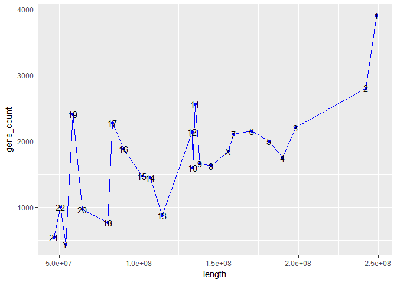

```r
merged[, c("seqid", "length", "gene_count")] %>%
  arrange(desc(length)) %>%
  ggplot(aes(x = length, y = gene_count, label = seqid)) +
  geom_point(color = "blue") +
  geom_line(color = "blue") +
  geom_text()
```